# Appendix

Effect of Tocilizumab, Sarilumab, and Baricitinib on Mortality Among Patients Hospitalized for COVID-19 Treated with Corticosteroids: A Systematic Review and Meta-Regression

Arthur M. Albuquerque, Igor Eckert BS, Lucas Tramujas MD, Guillaume Butler-Laporte MD, Emily G. McDonald MD MSc, James M. Brophy MD PhD, Todd C. Lee MD MPH

February 23, 2022

# Appendix Methods

## Search Strategy

**PubMed:**

| Query | Terms |
| --- | --- |
| #1 | (randomized controlled trial[pt] OR controlled clinical trial[pt] OR randomized[tiab] OR placebo[tiab] OR drug therapy[sh] OR randomly[tiab] OR trial[tiab] OR groups[tiab] NOT (animals [mh] NOT humans… |
| #2 | coronavirus[Title] OR "corona virus" [Title] OR "corona pandemic"[Title] OR coronavirinae[Title] OR coronaviridae[Title] OR betacoronavirus[Title] OR covid19[Title] OR covid[Title] OR nCoV[Title] OR "… |
| #3 | sarilumab[Title/Abstract] |
| #4 | baricitinib[Title/Abstract] |
| #5 | tocilizumab[Title/Abstract] |

Tocilizumab: #1 AND #2 AND #5

Sarilumab: #1 AND #2 AND #3

Baricitinib: #1 AND #2 AND #4

**CENTRAL:**

| Query | Terms |
| --- | --- |
| #1 | MeSH descriptor: [COVID-19] explode all trees |
| #2 | sarilumab with PubYear from 2021 to 2021, in Trials |
| #3 | baricitinib |
| #4 | tocilizumab with PubYear from 2021 to 2021, in Trials |

Tocilizumab: #1 AND #4

Sarilumab: #1 AND #2

Baricitinib: #1 AND #3

**EMBASE:**

| Query | Terms |
| --- | --- |
| #1 | ('crossover procedure'/exp OR 'crossover procedure') AND [embase]/lim OR (('prospective study'/exp OR 'prospective study') AND [embase]/lim) OR (('follow up'/exp OR 'follow up') AND [embase]/lim) OR (… |
| #2 | baricitinib':ti,ab |
| #3 | sarilumab':ti,ab |
| #4 | tocilizumab':ti,ab |
| #5 | coronavirus infection' OR 'coronavirus disease 2019' OR 'severe acute respiratory syndrome coronavirus 2' |

Tocilizumab: #1 AND #4 AND #5 AND 2021:py

Sarilumab: #1 AND #3 AND #5 AND 2021:py

Baricitinib: #1 AND #2 AND #5

**Medrxiv:**

| Query | Terms |
| --- | --- |
| #1 | (sarilumab OR baricitinib OR tocilizumab) AND (covid-19 OR coronavirus OR covid) AND random*" and abstract or title "random randomized randomly randomised placebo-controlled |

## Data Synthesis and Analysis

### Meta-analysis

For each set of studies (tocilizumab, baricitinib, or sarilumab vs. control), we fitted a Bayesian random-effects meta-analysis. Each model is defined as:

$$\begin{align*}
y_i & \sim Normal(\theta_i, \sigma_i^2)\\
\theta_i & \sim Normal(\mu, \tau^2)\\
\end{align*}$$

where $y_i$ is the observed mean log odds ratio in study $i$ for either tocilizumab, sarilumab, or baricitinib versus control treatment. We assume these effect sizes are normally distributed around the study-specific mean $\theta_i$ along with a known sampling variance, represented by the observed $\sigma_i^2$. We also assume $\theta_i$ is drawn from a normal distribution where $\mu$ is the average effect and $\tau^2$ is the between-study heterogeneity.

Then, the posterior predictive distribution can be described as:

$$\begin{align*}
\theta_{new} & \sim Normal(\mu, \tau^2)\\
\end{align*}$$

where $\theta_{new}$ “relates to the effect in a new study that is deemed ‘sufficiently similar’ to the existing studies to be eligible for the analysis”.

Because these are Bayesian models, we need to specify prior distributions for all parameters. We applied a prior for $\mu$ that cover plausible values, assigning limited density to unlikely values, and thereby exerting little influence on the results in all models. A simulation study supported by empirical evidence suggests that a prior with a 95% interval between $0.23$ and $4.35$ is suitable to this case. In the log scale, such prior is described as:

$$\begin{align*}
\mu & \sim \operatorname{Normal}(0, 0.75^2)
\end{align*}$$

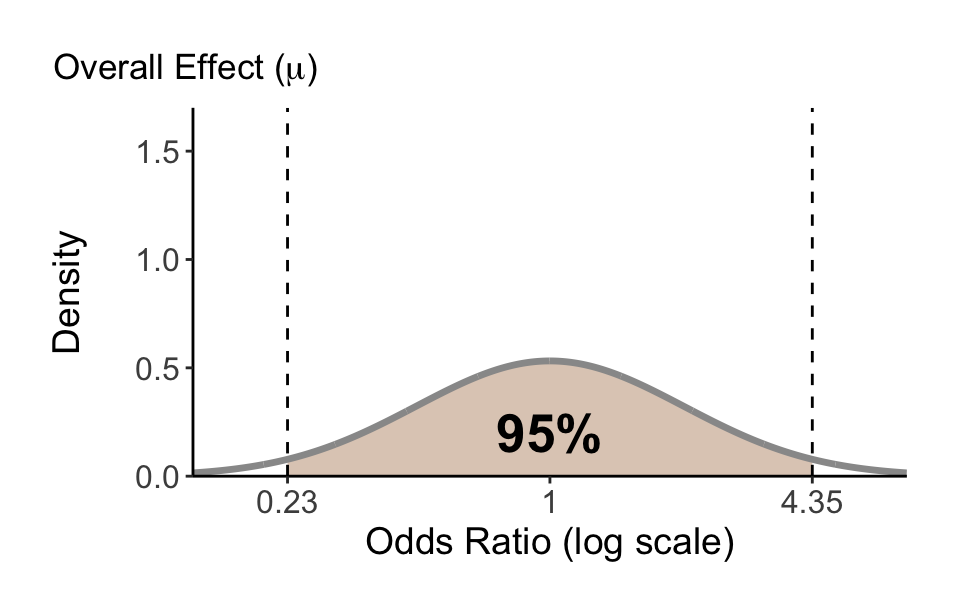

Regarding the between-study standard deviation parameter ($\tau$), we used an informative prior based on previous evidence. We applied the predictive distribution on all-cause mortality for “placebo / control” vs. “pharmacological” comparisons derived by Turner et al.. Although the definition of small or large between-study heterogeneity is arbitrary, previous work suggests cutoff values (“reasonable” heterogeneity between 0.1 and 0.5, and “fairly high” between 0.5 and 1.0. We added a category for low heterogeneity (between 0 and 0.1):

$$\begin{align*}
\tau & \sim \operatorname{Log-Normal}(-1.975, 0.67^2)
\end{align*}$$

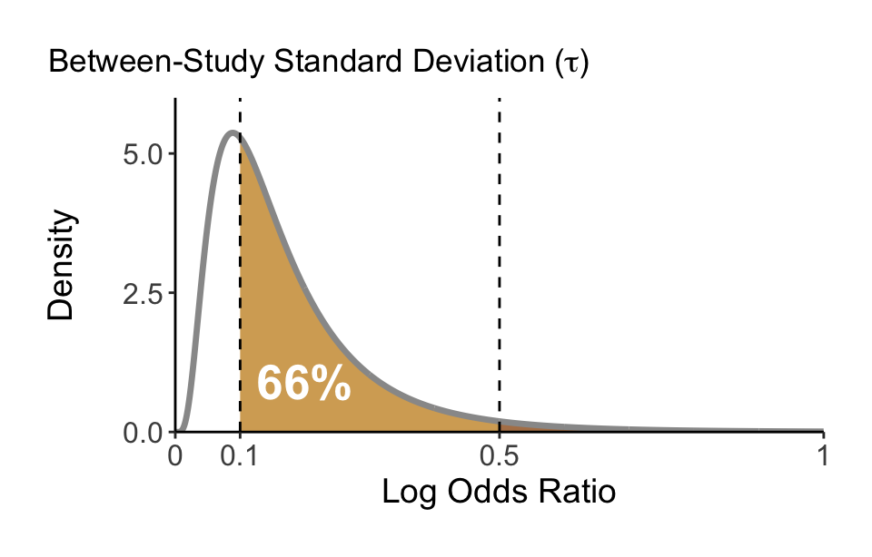

While maintaining the same prior for $\mu$, we added a post-hoc sensitivity analysis using a less informative prior for $\tau$:

$$\begin{align*}
\tau & \sim \operatorname{Half-Normal}(0, 0.5^2)
\end{align*}$$

This distribution yields higher heterogeneity probabilities, while limiting less plausible high levels.

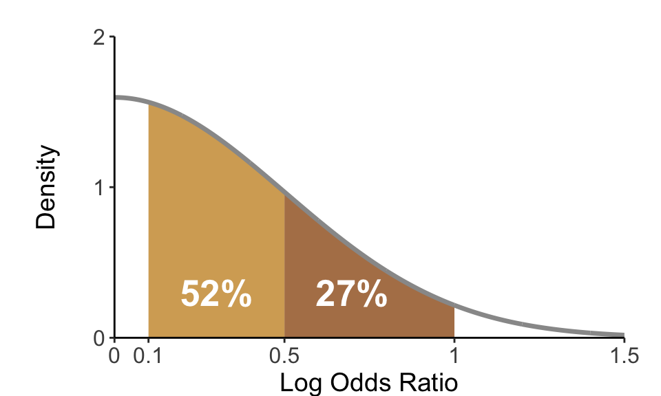

This distribution concentrates 16% of probability density between 0 and 0.1 log odds ratio (‘low heterogeneity’), 52% between 0.1 and 0.5 (‘reasonable’), and 27% between 0.5 and 1.0 (‘fairly high’).

#### Posterior predictive distribution

To further explore the impact of between-study heterogeneity, we evaluated the posterior predictive distribution in each meta-analysis. This distribution allows inference about “…what we would expect to see in a new study population that is exchangeable with the studies included in our meta-analysis”.

$$\theta_{new} \sim \operatorname{Normal}(\mu, \tau^2)$$

The posterior predictive distribution estimates true treatment effects (study populations, $\theta_{new}$) expected in future settings. This distribution is vital to inform probable values for the true treatment association in future settings, valuable for power calculations or prior distribution elicitation in future RCTs. This generates new trial population parameter estimates, independently of sample size and other population characteristics.

### Meta-regression

Our primary research question is whether baricitinib and sarilumab are noninferior to tocilizumab. A sensitive approach to answer this question is to separately meta-analyze direct comparisons between tocilizumab vs. baricitinib and tocilizumab vs. sarilumab. However, a preliminary search by our research group showed a limited number of studies that report such comparisons. Thus, we decided to only estimate the noninferiority probability of sarilumab and baricitinib vs. tocilizumab through indirect (across-trials) comparisons. Because of the fragility of such comparisons, it is of great interest to test the robustness of these estimates with multiple prior distributions.

Bayesian network meta-analyses are historically used to estimate direct, indirect, and mixed-effects when more than two treatment comparisons are available. However, this approach does not allow one to assign prior distributions to specific comparisons within the network, such as an indirect effect. To overcome this limitation, we fitted Bayesian random-effect meta-regression models to estimate the indirect differences mentioned above (two separate sets of models: tocilizumab vs. baricitinib; tocilizumab vs. sarilumab). These models are identical to meta-regressions with a dichotomous covariate used to evaluate subgroup differences. This approach allows one to apply a plethora of prior distributions specifically to the indirect comparison between treatments.

Both baricitinib and sarilumab models are identical, and are described as:

$$\begin{align*}
y_i & \sim Normal(\theta_i, \sigma_i^2)\\
\theta_i & \sim Normal(\mu, \tau^2)\\
\mu &= \beta_0 + \beta_{1, T} x_i\\
\end{align*}$$

where $y_i$ is the observed mean log odds ratio in study $i$ for either tocilizumab, sarilumab, or baricitinib versus control treatment. We assume these effect sizes are normally distributed around the study-specific mean $\theta_i$ along with a known sampling variance, represented by the observed $\sigma_i^2$. We also assume $\theta_i$ is drawn from a normal distribution where $\mu$ is the average effect and $\tau^2$ is the between-study heterogeneity. We will estimate $\mu$ as a function of the estimated population effect size $\beta_0$ and the moderator $x$ multiplied by the coefficient $\beta_{1, T}$. $x$ is dummy-coded, where **0** indicates that the observed $y_i$ is an effect size estimate of **tocilizumab** compared to control, while **1** indicates that $y_i$ is an effect size estimate of the **sarilumab** ($T = Sari$) or **baricitinib** ($T = Bari$) compared to control.

In summary, we can estimate the overall log odds ratio for tocilizumab, sarilumab, and baricitinib (depending on which model) as:

- Tocilizumab = $\beta_0$
- Sarilumab = $\beta_0 + \beta_{1, Sari}$
- Baricitinib = $\beta_0 + \beta_{1, Bari}$

$\beta_{1, T}$ is the parameter that estimates the indirect difference between tocilizumab vs. sarilumab or tocilizumab vs. baricitinib. When exponentiated, $\beta_{1, T}$ yields the ratio of odds ratios, as demonstrated below. We will reference sarilumab and baricitinib as “comparator” hereafter.

$$\begin{gather*}
\beta_{1, T} = ln(OR_{comparator}) - ln(OR_{tocilizumab}) = ln(\frac{OR_{comparator}}{OR_{tocilizumab}})\\
exp(\beta_{1, T}) = \frac {OR_{comparator}}{OR_{tocilizumab}}
\end{gather*}$$

#### Priors

$\beta_0$ represents the log odds ratio for tocilizumab vs. control ($\ln[OR_{tocilizumab}]$). Here, we applied the same prior mentioned before (regarding $\mu$) for $\beta_0$:

$$\begin{align*}
\beta_0 & \sim \operatorname{Normal}(0, 0.75^2)
\end{align*}$$

Regarding the between-study standard deviation parameter ($\tau$), we also used the same informative prior mentioned before:

$$\begin{align*}
\tau & \sim \operatorname{Log-Normal}(-1.975, 0.67^2)
\end{align*}$$

In addition to the parameters mentioned above, we should also assign a prior distribution for the indirect comparison parameter ($\beta_{1, T}$). Inspired by the guidelines provided by Zampieri et al., we fitted different models to represent distinct beliefs. Before discussing these prior distributions, we will first elucidate the underlying rationale of this parameter.

A log odds ratio lower than $0$ represents lower mortality in the intervention arm (tocilizumab, sarilumab, or baricitinib) in comparison to control. Moreover, the indirect comparison parameter represents the absolute difference between comparator (sarilumab or baricitinib) and tocilizumab studies in the log scale. Therefore, when the mortality reduction due to intervention is greater in comparator studies (lower $\ln[OR_{comparator}]$ than $ln[OR_{tocilizumab}]$), $\beta_{1, T}$ is negative in the log scale:

$$\begin{align*}
\downarrow \ln(OR_{comparator}) - \uparrow \ln(OR_{tocilizumab}) \rightarrow -\beta_{1, T}\\
\end{align*}$$

Here is the same rationale in the linear scale to further facilitate $\beta_{1, T}$’s prior elicitation:

$$\begin{align*}
exp(\beta_{1, T}) &= ROR = \frac {OR_{comparator}}{OR_{tocilizumab}}
\end{align*}$$

where ROR is the ratio of odds ratios, i.e. the interaction parameter exponentiated ($exp[\beta_{1, T}]$). Thus, a ROR lower than $1$ also indicates greater mortality reduction due to intervention in comparator studies:

$$\begin{align*}
\frac {\downarrow OR_{comparator}}{\uparrow OR_{tocilizumab}} \rightarrow ROR < 1
\end{align*}$$

We separately applied $4$ normally distributed prior distributions for $\beta_{1, T}$ in each model (sarilumab and baricitinib’s models), which can be described based on the “prior belief” and “belief strength”. While the former reflects the distribution’s mean, the latter reflects the distribution’s standard deviation.

In the model comparing **sarilumab** to tocilizumab, the beliefs are:

- “Skeptical”, which expects no difference between sarilumab and tocilizumab studies (mean centered at $1$) with $95\%$ probability between $0.5$ and $2$ (linear scale, ratio of odds ratios). These values represent a weak belief strength, based on the little information currently available on this topic. $\operatorname{Normal}(0, 0.354^2)$
- “Optimistic for Sarilumab”, which expects a greater mortality reduction due to sarilumab use in comparison to tocilizumab. The mean is centered at $0.952$ (linear scale, ratio of odds ratios), which was based on the single study that directly compared sarilumab to tocilizumab (REMAP-CAP). In this study, they assessed “hospital survival” and an odds ratio greater than 1 indicated greater in-hospital mortality reduction due to sarilumab use in comparison to tocilzumab. As shown in their Figure S3, the median odds ratio of sarilumab vs. tocilizumab was 1.05, indicating a greater odds of hospital survival due to sarilumab. However, in the present study, we will assess mortality (not hospital survival), and an odds ratio lower (not greater) than 1 represents greater mortality reduction due to sarilumab use. Thus, to guide this belief based on the study mentioned above, we calculated the reciprocal of 1.05 ($1/1.05$), which yields $0.952$. $\operatorname{Normal}(-0.049, 0.193^2)$

  Further, we considered that there is 40% of probability that the ratio of odds ratios is greater than $1$. We chose 40% because the single study that directly compared sarilumab to tocilizumab found 34% of probability density for tocilizumab’s superiority over sarilumab. However, this was the first and only study and therefore likely to be an over-estimate and not to include potential between study variability. We then elected to see a 40% of probability for tocilizumab’s superiority over sarilumab in this prior as being a “realistic optimistic for Sarilumab” prior. . Although not identical to the 30% suggested by Zampieri et al. – which we consider too informative in this case, given that it would be more informative than the study mentioned above – we believe this prior represents weak belief strength.
- “Optimistic for Tocilizumab”, which expects a greater mortality reduction due to tocilizumab use in comparison to sarilumab. The mean is centered at $1.05$, the reciprocal of $0.952$. Similarly, this prior belief will also have a weak strength, represented by 40% of probability that the ratio of odds ratios is lower than $1$. $\operatorname{Normal}(0.049, 0.193^2)$
- “Vague”, which represents no prior belief with no strength. $\operatorname{Normal}(0, 4^2)$

The first three distributions are shown below:

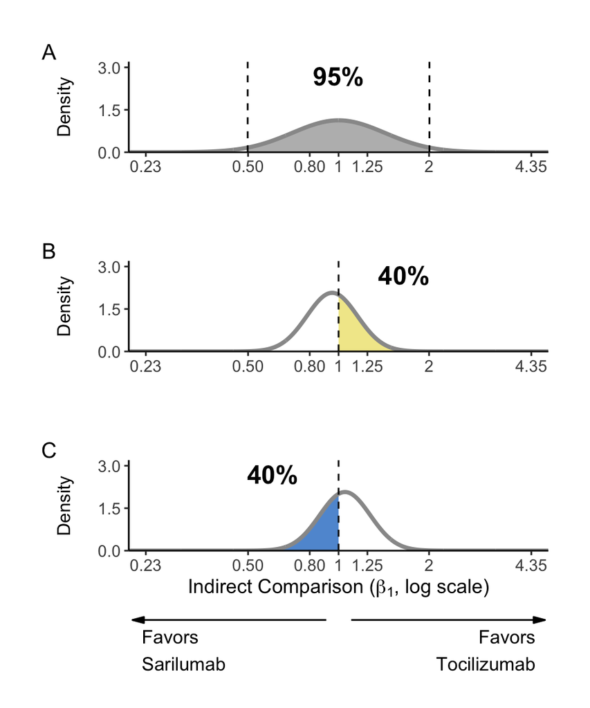

Prior distributions for $beta_{1, Sari}$ (ratio of odds ratios) in models comparing sarilumab to tocilizumab. Panel A: ‘Skeptical’ prior. The Normal($0$, $0.354^2$) distribution approximately concentrates $95$% of probability density between $0.5$ and $2.0$ in the linear scale ($-0.69$ and $0.69$ in the log scale, respectively). Panel B: ‘Optimistic for Sarilumab’ prior. The Normal($-0.049$, $0.193^2$) distribution approximately concentrates $40$% of probability density above $1$. Panel C: ‘Optimistic for Tocilizumab’ prior. The Normal($0.049$, $0.193^2$) distribution approximately concentrates $40$% of probability density below $1$.

In the model comparing **baricitinib** to tocilizumab, the beliefs are:

- “Skeptical”, which expects no difference between baricitinib and tocilizumab studies (mean centered at $1$) with $95\%$ probability between $0.5$ and $2$ (linear scale, ratio of odds ratios). These values represent a weak belief strength, based on the little information currently available on this topic. $\operatorname{Normal}(0, 0.354^2)$
- “Optimistic for Baricitinib”, which expects a greater mortality reduction due to baricitinib use in comparison to tocilizumab. The mean is centered at $0.9$ (linear scale, ratio of odds ratios), which was arbitrarily chosen based on clinical judgment that a 10% relative difference is clinically important. Because there was no information previously available, we considered that there is 40% of probability that the ratio of odds ratios is greater than 1, representing a weak belief strength. $\operatorname{Normal}(-0.105, 0.416^2)$
- “Optimistic for Tocilizumab”, which expects a greater mortality reduction due to tocilizumab use in comparison to sarilumab. The mean is centered at $1.11$, the reciprocal of $0.9$. Similarly, this prior belief will also have a weak strength, represented by 40% of probability that the ratio of odds ratios is lower than $1$. $\operatorname{Normal}(0.105, 0.416^2)$
- “Vague”, which represents no prior belief with no strength. $\operatorname{Normal}(0, 4^2)$

The first three distributions are shown below:

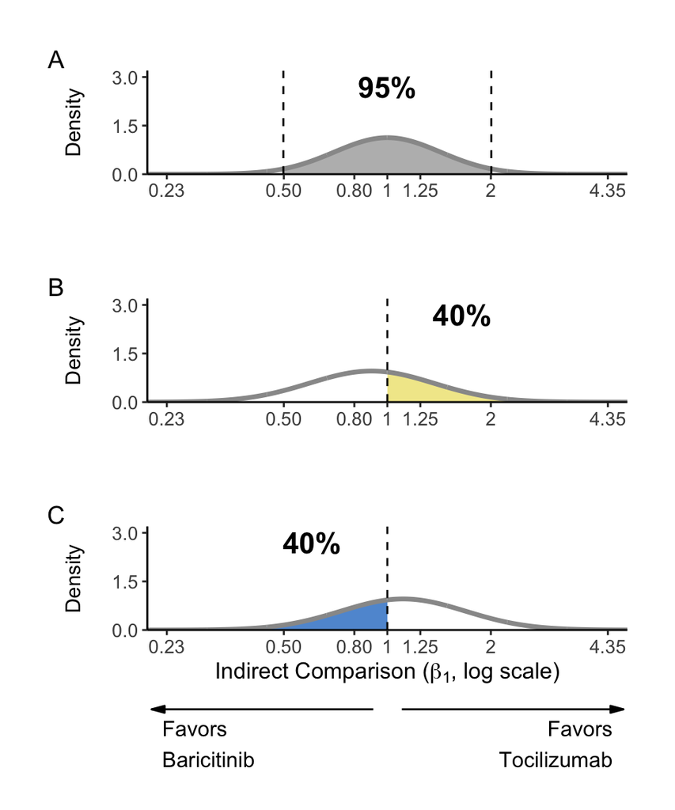

Prior distributions for $beta_{1, Bari}$ (ratio of odds ratios) in models comparing baricitinib to tocilizumab. Panel A: ‘Skeptical’ prior. The Normal($0$, $0.354^2$) distribution approximately concentrates $95$% of probability density between $0.5$ and $2.0$ in the linear scale ($-0.69$ and $0.69$ in the log scale, respectively). Panel B: ‘Optimistic for Baricitinib’ prior. The Normal($-0.105$, $0.41^2$) distribution approximately concentrates $40$% of probability density above $1$. Panel C: ‘Optimistic for Tocilizumab’ prior. The Normal($0.105$, $0.41^2$) distribution approximately concentrates $40$% of probability density below $1$.

In summary, both sarilumab and baricitinib models can be fully described as:

$$\begin{align*}
y_i & \sim Normal(\theta_i, \sigma_i^2)\\
\theta_i & \sim Normal(\mu, \tau^2)\\
\mu &= \beta_0 + \beta_{1, T} x_i\\
\end{align*}$$

while the priors in sarilumab’s models are:

$$\begin{align*}
\beta_0 & \sim \operatorname{Normal}(0, 0.75^2)\\
\tau & \sim \operatorname{Log-Normal}(-1.975, 0.67^2)\\
\beta_{1, Sari[Skeptical]} & \sim \operatorname{Normal}(0, 0.354^2)\\
\beta_{1, Sari[Sarilumab]} & \sim \operatorname{Normal}(-0.049, 0.193^2)\\
\beta_{1, Sari[Tocilizumab]} & \sim \operatorname{Normal}(0.049, 0.193^2)\\
\beta_{1, Sari[Vague]} & \sim \operatorname{Normal}(0, 4^2)
\end{align*}$$

and the priors in baricitinib’s models are:

$$\begin{align*}
\beta_0 & \sim \operatorname{Normal}(0, 0.75^2)\\
\tau & \sim \operatorname{Log-Normal}(-1.975, 0.67^2)\\
\beta_{1, Bari[Skeptical]} & \sim \operatorname{Normal}(0, 0.354^2)\\
\beta_{1, Bari[Baricitinib]} & \sim \operatorname{Normal}(-0.105, 0.416^2)\\
\beta_{1, Bari[Tocilizumab]} & \sim \operatorname{Normal}(0.105, 0.416^2)\\
\beta_{1, Bari[Vague]} & \sim \operatorname{Normal}(0, 4^2)
\end{align*}$$

where all parameters are in the log scale.

One could argue that baricitinib’s priors are stronger than sarilumab’s given differences on the mean values ($|0.105| > |0.049|$). We note that, although the mean values are different because we only found prior evidence for the sarilumab vs. tocilizumab comparison, these prior discrepancies are likely to be of little relevance. As depicted in the figures above, the baricitinib’s priors have a greater mean but lower density than sarilumab’s priors. Therefore, we do not expect these priors’ impact on each marginal posterior distribution to be relevantly different.

#### Post-hoc sensitivity analysis

Regarding the sarilumab vs. tocilizumab meta-regression model, we also performed a post-hoc sensitivity analysis with a different set of priors.

We fitted the exact same model, but with different “Optimistic for Sarilumab” and “Optimistic for Tocilizumab” priors (hereafter, “Optimistic for Sarilumab (REMAP-CAP)” and “Optimistic for Tocilizumab (inverse REMAP-CAP)”:

$$\begin{align*}
y_i & \sim Normal(\theta_i, \sigma_i^2) \tag{Likelihood}\\
\theta_i & \sim Normal(\mu, \tau^2)\\
\mu &= \beta_0 + \beta_{1, Sari} x_i\\
\\
\beta_0 & \sim \operatorname{Normal}(0, 0.75^2) \tag{Priors}\\
\tau & \sim \operatorname{Log-Normal}(-1.975, 0.67^2)\\
\beta_{1, Sari[Sarilumab]} & \sim \operatorname{Normal}(-0.049, 0.118^2)\\
\beta_{1, Sari[Tocilizumab]} & \sim \operatorname{Normal}(0.049, 0.118^2)\\
\end{align*}$$

These priors were constructed to reflect the exact same strength of the single study that directly compared sarilumab to tocilizumab.

The new standard deviation of $0.118$ was obtained through the formula:

$$\sigma = \frac{\ln(\operatorname{UCL}) - \ln(\operatorname{LCL})}{3.92}$$

where $UCL$ is $1.35$, and $LCL$ is $0.85$, as depicted in the Figure S3 of the RCT cited above (REMAP-CAP). In comparison to the 40% probability density above/below $1.0$ yielded by the main priors in the section before, these sensitivity priors yield $34\%$, highlighting its greater strength.

#### Noninferiority analysis

Our primary goal is to assess whether sarilumab and baricitinib are noninferior to tocilizumab. Thus, we calculated the posterior probabilities of noninferiority based on the marginal posterior distributions of $\beta_{1, T}$ in all models and scenarios described above.

One major criteria in noninferiority analyses is that superiority of active comparator — in this case, tocilizumab — in comparison to control has been shown.. The WHO meta-analysis presented results in favor of tocilizumab’s superiority. Thus, we will use the following formula to estimate our noninferiority margin:

$$\begin{align*}
\gamma = \left( \frac{1}{\theta} \right)^{1 - x} \\
\end{align*}$$

where $\gamma$ is the estimated noninferiority margin, $\theta$ is the tocilizumab’s mean effect size, and $x$ is the percentage of tocilizumab’s effect that is desired to be preserved. Regarding $\theta$, we extracted the mean odds ratio regarding tocilizumab’s effect in the subgroup of patients using corticosteroids (page 14 in their Supplement 2 ). We chose this subgroup because it represents our population of interest. Moreover, we will follow the U.S. Department of Health and Human Services Food and Drug Administration’s recommendation and define $x$ as $50\%$ for our primary noninferiority analysis. Thus, our main noninferiority margin (in the linear scale) will be:

$$\begin{align*}
\gamma = \left( \frac{1}{0.77} \right)^{0.5} = 1.139606 \\
\end{align*}$$

# Appendix Results

## Appendix Figure 1

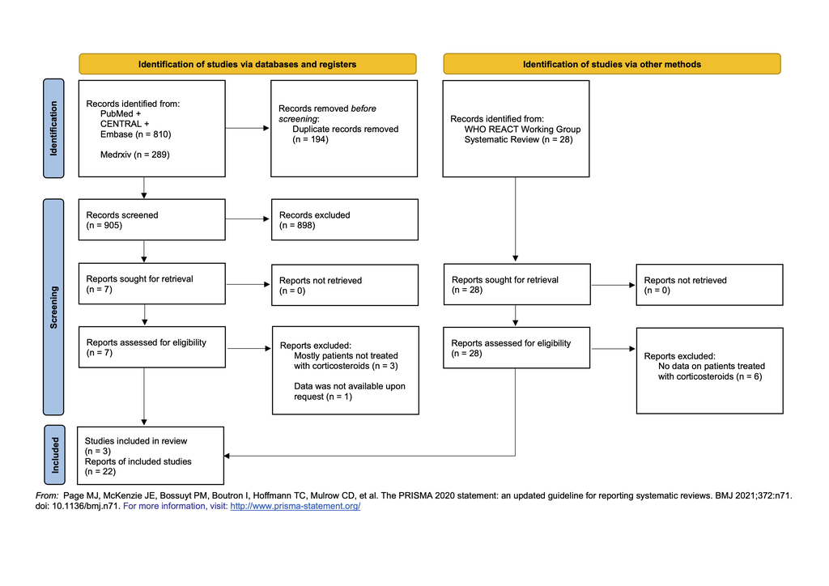

PRISMA 2020 flow diagram with results from our search process.

## Appendix Figure 2

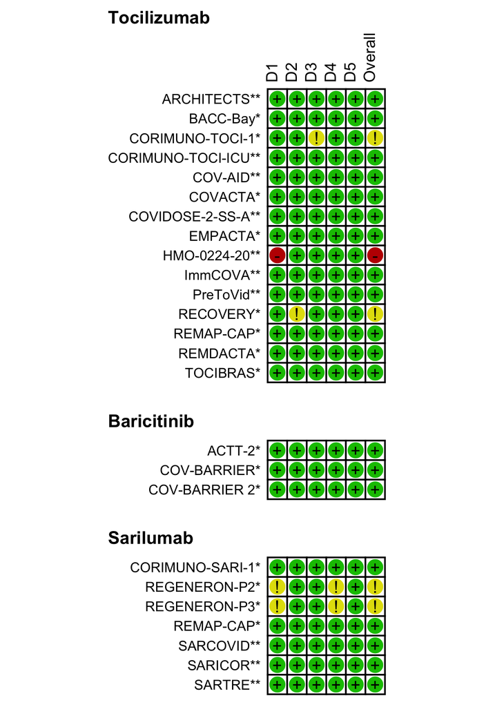

Risk of bias for domain-level as well as overall judgement for each individual study.

D1: bias arising from randomisation process; D2: bias arising from deviations from intended interventions; D3: bias due to missing outcome data; D4: bias in measurement of the outcome; D5: bias in selection of the reported result.

“+” depicts “Low” risk, while “!” and “-” indicate “Some concerns” and “High”, respectively.

Studies with * indicate that the risk of bias assessment was performed by our research group. In contrast, ** indicates that the assessment was performed by the WHO React Working Group, as explained in our Methods section.

## Appendix Figure 3

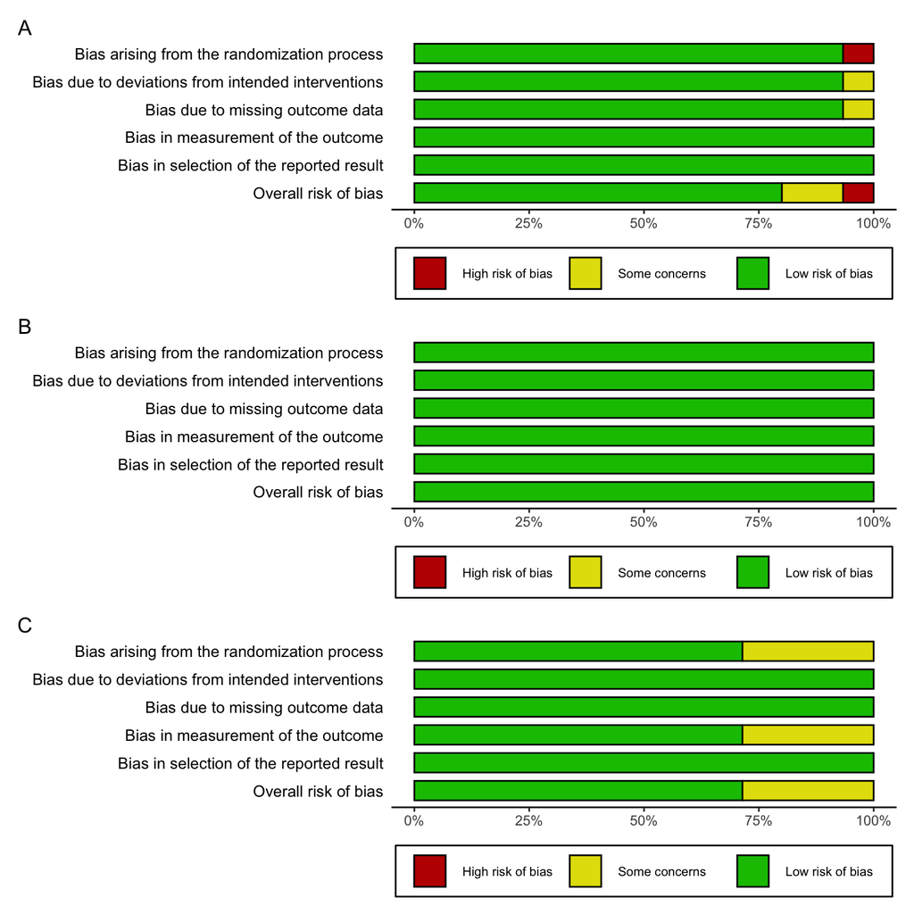

Distributions of proportions of risk of bias within each domain. Panel A: Tocilizumab studies; Panel B: Baricitinib; Panel C: Sarilumab.

## Appendix Figure 4

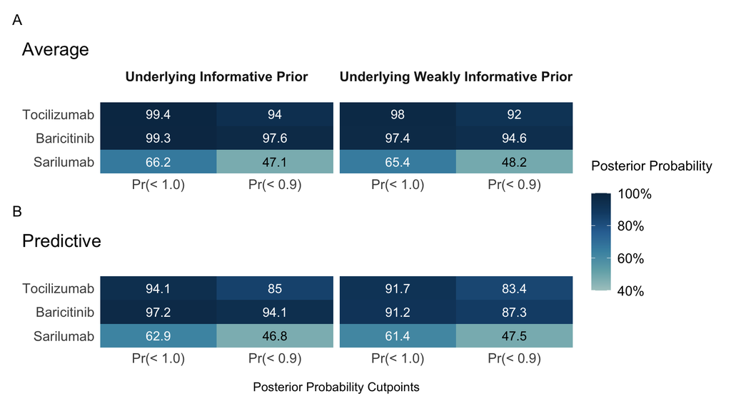

Heatmaps with posterior probabilities of tocilizumab, baricitinib, and sarilumab meta-analyses’ average (Panel A) and predictive effect (Panel B). *“Pr(< 1.0)”* depicts probabilities of any benefit (< 1.0 odds ratio [OR]), and *“Pr(< 0.9)”* depicts probabilities of clinically meaningful benefit (< 0.9 OR). The exact probability is shown in each cell, while darker colors correspond to higher probabilities.

Heatmaps on the left regard models assuming a more informative prior ($\operatorname{Log-Normal}[-1.975, 0.67^2]$) for the between-study standard deviation, while heatmaps on the right regard models with weakly informative prior ($\operatorname{Half-Normal}[0.5^2]$). All models assume a $Normal(0, 0.75^2)$ prior distribution for average effect ($mu$).

## Appendix Figure 5

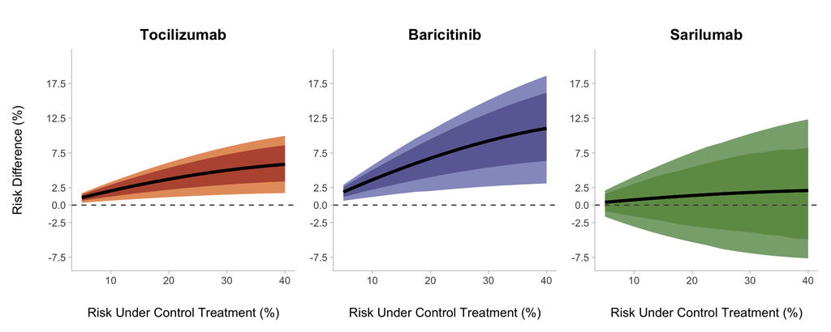

Meta-analysis average effect posterior distributions in the risk difference scale (Y-axis) across multiple mortality risks under control treatment (X-axis) for each experimental drug. Black solid lines represent the median, darker colored areas represent the 80% CrIs, and lighter areas represent the 95% CrIs. Risk difference greater than 0 favors experimental drug over control.

Underlying prior distributions are $Normal(0, 0.75^2)$ for the average effect ($\mu$), and $\operatorname{Log-Normal}[-1.975, 0.67^2]$ for the between-study standard deviation ($\tau$).

## Appendix Figure 6

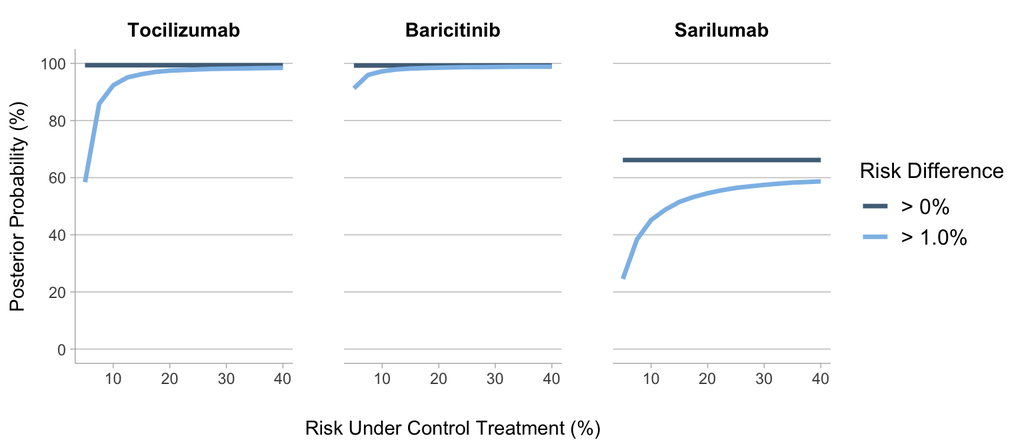

Posterior probabilities of benefit or equivalence in the risk difference scale. Each line represents the posterior probability for a specific cutpoint, such as risk difference greater than 0% or 1%. across multiple mortality risks under control treatment.

Underlying prior distributions are $Normal(0, 0.75^2)$ for the average effect ($\mu$), and $\operatorname{Log-Normal}[-1.975, 0.67^2]$ for the between-study standard deviation ($\tau$).

## Appendix Figure 7

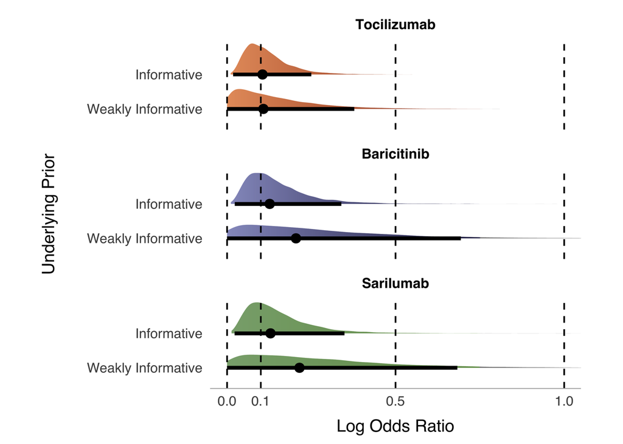

Between study standard deviation ($\tau$) posterior distributions upon different underlying prior distributions (informative or weakly informative) for $\tau$. This parameter is an estimate for between-study heterogeneity in random-effect meta-analyses. Point estimates depict the median, while intervals bars 95% CrIs. Dashed lines represent different heterogeneity ranges: from 0 to 0.1 log odds ratio, “Low heterogeneity”; from 0.1 to 0.5, “Reasonable”; from 0.5 to 1.0, “Fairly High”.

For $\tau$, the “Informative” prior regards a $\operatorname{Log-Normal}(-1.975, 0.67^2)$ distribution, while “Weakly Informative” regards a $\operatorname{Half-Normal}(0.5)$ distribution. All models assume a $Normal(0, 0.75^2)$ prior distribution for average effect ($mu$).

## Appendix Table 1

#### Posterior Probabilities of Heterogeneity in Each Meta-Analysis

|  | Posterior Probability within Heterogeneity Ranges, % Low | Posterior Probability within Heterogeneity Ranges, % Reasonable | Posterior Probability within Heterogeneity Ranges, % Fairly High |
| --- | --- | --- | --- |
| Tocilizumab |  |  |  |
| Informative | 46.3 | 53.6 | 0.0 |
| Weakly Informative | 46.9 | 51.6 | 1.5 |
| Baricitinib |  |  |  |
| Informative | 34.8 | 64.2 | 1.0 |
| Weakly Informative | 26.9 | 59.8 | 12.4 |
| Sarilumab |  |  |  |
| Informative | 34.5 | 64.5 | 1.0 |
| Weakly Informative | 24.6 | 61.7 | 13.2 |

Low heterogeneity range: between 0 and 0.1 log odds ratio; Reasonable range: between 0.1 and 0.5; Fairly high: between 0.5 and 1.0.  
Informative Between-study SD Prior: LN(-1.975, 0.67); Weakly Informative Prior: HN(0.5); LN(mu, SD) = Log-Normal(mean, standard deviation); HN(SD) = Half-Normal(standard deviation)

## Appendix Table 2

#### Posterior Credible Intervals in Each Meta-Analysis

| Treatment / Prior | Posterior Results, Median and 95% CrI Average Effect<sup>1</sup> | Posterior Results, Median and 95% CrI Between-study SD<sup>2</sup> | Posterior Results, Median and 95% CrI Predictive Effect<sup>1</sup> |
| --- | --- | --- | --- |
| Tocilizumab |  |  |  |
| Informative | 0.78 [0.64, 0.93] | 0.11 [0.02, 0.25] | 0.78 [0.55, 1.07] |
| Weakly Informative | 0.78 [0.62, 0.96] | 0.11 [0, 0.38] | 0.78 [0.44, 1.15] |
| Baricitinib |  |  |  |
| Informative | 0.61 [0.4, 0.87] | 0.13 [0.02, 0.34] | 0.61 [0.33, 0.96] |
| Weakly Informative | 0.62 [0.34, 0.94] | 0.2 [0, 0.69] | 0.61 [0.15, 1.26] |
| Sarilumab |  |  |  |
| Informative | 0.92 [0.54, 1.33] | 0.13 [0.02, 0.35] | 0.92 [0.48, 1.52] |
| Weakly Informative | 0.91 [0.49, 1.39] | 0.21 [0, 0.68] | 0.92 [0.28, 1.83] |

Informative Between-study SD Prior: LN(-1.975, 0.67); Weakly Informative Prior: HN(0.5); LN(mu, SD) = Log-Normal(mean, SD); HN(SD) = Half-Normal(SD)  
Abbreviations: SD, standard deviation; CrI, credible interval  
<sup>*1*</sup> Odds Ratio <sup>*2*</sup> Log Odds Ratio

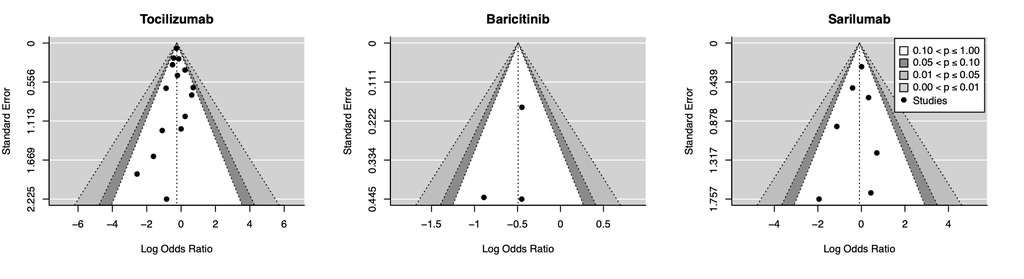

Contour-enhanced funnel plots for small study effect assessment.

## Appendix Table 3

Certainty of evidence (GRADE) assessment

| Drug | Risk of Bias | Heterogeneity | Imprecision | Indirectness | Publication Bias | Judgment |
| --- | --- | --- | --- | --- | --- | --- |
| Tocilizumab | We did not downgrade as the most weighted studies were judged as low risk of bias. | Certainty was downgraded by 2 levels due to serious heterogeneity as the prediction interval suggests future studies could estimate different results leading to opposite clinical decisions (upper boun… | We did not downgrade due to imprecision, although by a close call, despite reasonably large confidence intervals (35% reduction to 6% reduction in mortality) as the upper bound of the CI suggests clin… | We did not find compelling evidence to downgrade due to indirectness. | We did not find compelling evidence to downgrade due to publication bias. | LOW QUALITY OF EVIDENCE, downgraded by 2 levels due to serious heterogeneity |
| Baricitinib | We did not downgrade as the study contributing the most to the final result (COV-BARRIER), out of 3 studies, was judged as low risk of bias. | We did not downgrade, although by a close call, based on heterogeneity alone: point estimates are reasonably similar; heterogeneity as evidenced by tau is reasonable; the impact of the heterogeneity, … | We did not downgrade, although by a close call, based on imprecision alone: clinical decision would likely not differ from worst-case (OR = 0.89) to best case (OR = 0.42) scenarios within the confiden… | We did not find compelling evidence to downgrade due to indirectness. | We did not find compelling evidence to downgrade due to publication bias. | MODERATE QUALITY OF EVIDENCE, downgraded 1 level due to imprecision and heterogeneity (two close calls) |
| Sarilumab | We did not downgrade as the most weighted studies were judged as low risk of bias. | Certainty was downgraded by 1 level due to substantial variability in point estimates, both in magnitude and direction of effect. | Certainty was downgraded by 2 levels due to serious imprecision (the confidence interval includes both clinically relevant benefits and harms). | We did not find compelling evidence to downgrade due to indirectness. | We did not find compelling evidence to downgrade due to publication bias. | VERY LOW QUALITY OF EVIDENCE, downgraded by 1 level due to heterogeneity and 2 levels due to serious imprecision. |

## Appendix Figure 9

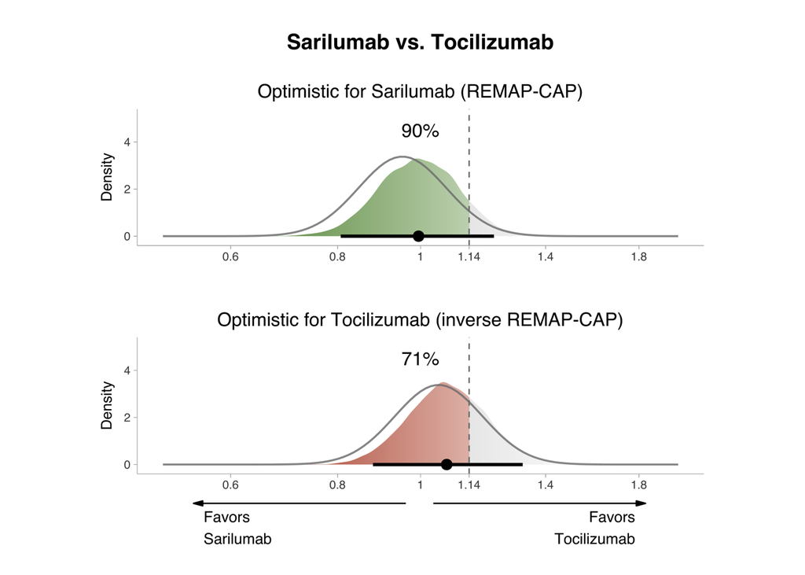

Post-hoc sensitivity analysis on sarilumab vs. tocilizumab meta-regression model (ratio of odds ratios). Color filled curves represent the posterior distributions. Color filled areas represent the posterior probability of noninferiority (Pr < 1.14), as the percentages on top of each panel. Lastly, interval bars depict the posterior median and 95% credible intervals.

REMAP-CAP is an RCT that directly compared sarilumab to tocilizumab and found results favoring sarilumab. We therefore created a prior distribution to incorporate these results (“Optimistic for Sarilumab (REMAP-CAP”)), and its inverse (“Optimistic for Tocilizumab (inverse REMAP-CAP”)), as further explained in the Appendix Methods.

## Appendix Table 4

#### Posterior Credible Intervals, Sarilumab Meta-Regression Sensitivity Analysis

| Belief | ROR (95% CrI) | Probability of Noninferiority, %<sup>1</sup> | Probability of Superiority, %<sup>2</sup> |
| --- | --- | --- | --- |
| Optimistic for Sarilumab (REMAP-CAP) | 0.99 (0.8, 1.21) | 90 | 52 |
| Optimistic for Tocilizumab (inverse REMAP-CAP) | 1.07 (0.88, 1.31) | 71 | 25 |

Abbreviations: ROR, ratio of odds ratios; CrI, credible interval  
<sup>*1*</sup> Posterior probability below the noninferiority margin (1.14 ROR) <sup>*2*</sup> Posterior probability below 1.00 ROR

## Appendix Figure 10

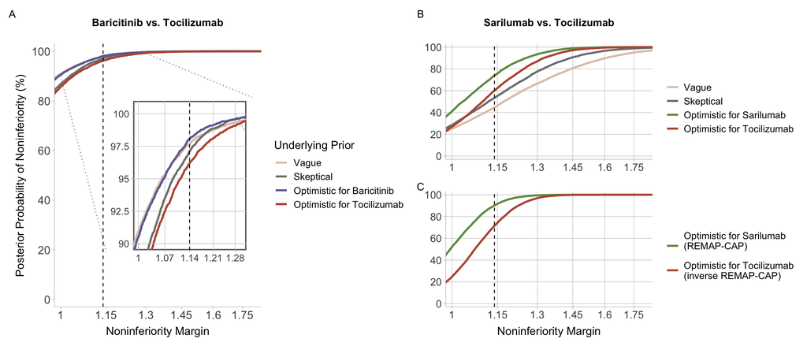

Posterior probabilities (Y-axis) across multiple noninferiority margins (X-axis) of meta-regressions models. Each curve represents a different analysis based on the underlying prior distribution. The dashed black line represents the main noninferiority margin (1.14 ratio of odds ratios). Panel A depicts results regarding baricitinib vs. tocilizumab analyses. There is a zoomed-in panel to better represent differences shown between 1.0 and 1.28 margins on the X-axis, and between 90 and 100% on the Y-axis. Panel B depicts results regarding sarilumab vs. tocilizumab main analyses. Panel C depicts results regarding sarilumab vs. tocilizumab post-hoc sensitivity analyses.